# Matching Methodology

Giancarlo D’Agostino

2026-03-27

# Matching

Based on the Kaplan-Meier curves made in the survival analysis markdown, we have decided to move forward with matching as a way of controlling for confounding variables. Throughout this markdown, the `survival` and `survminer` packages will be used.

Matching will be used in this study due to the nature of our data and our research question. As mentioned in ‘02_survival-analysis.Rmd,’ we are using KM curves not to evaluate survival after treatment, but to compare survival rates between soldiers with tuberculosis versus without. Therefore, our first event cannot be first mention of TB for both cohorts, since the non-TB group won’t have a diagnosis date. We will use an `index_date` after matching the TB-afflicted soldiers to a healthy soldier with the most common traits.

## Matching Methodology

In order to have robust matching results, we have decided to go variable-by-variable for characteristics to match by. The first one will be birth year, to control for age. We will try to match by exact year and also by nearest neighbor.

```r
# Clean matching dataframe
match_byr <- surv_tb |>
  select(
    recidnum,
    tb_first_date, age_tb, age_death,
    BYR, DYR, initstat, TB_yn, wnd_yn, lst1_hgt
  ) |>
  mutate(
    TB_yn = as.numeric(as.character(TB_yn)),
    BYR = as.numeric(as.character(BYR))
  ) |>
  drop_na(BYR, DYR) |>
  filter(is.finite(BYR))


# Diagnostics before matching
nrow(match_byr |> filter(TB_yn == 1))
```

```
## [1] 2287
```

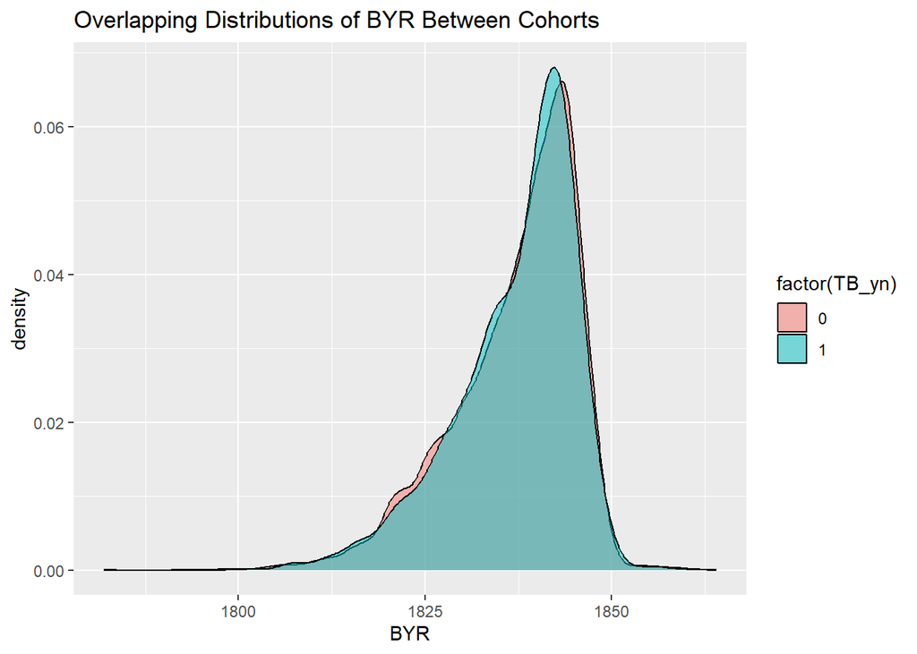

```r
ggplot(match_byr, aes(x = BYR, fill = factor(TB_yn))) +
  geom_density(alpha = 0.5) +
  labs(title = "Overlapping Distributions of BYR Between Cohorts")
```

```r
# Run model
model_byr <- matchit(TB_yn ~ BYR,
                      data = match_byr,
                      distance = "glm",
                      link = "probit",
                      exact = ~BYR)
```

```r
# INDEX
matched_df <- index(model_byr)

check_random_pairs(matched_df, n_pairs = 5)
```

```
## # A tibble: 10 × 17
##    recidnum   tb_first_date age_tb age_death   BYR   DYR initstat TB_yn wnd_yn
##    <chr>              <dbl>  <dbl>     <dbl> <dbl> <dbl> <chr>    <dbl>  <int>
##  1 2419507028          1865     26        67  1839  1906 OH           1      0
##  2 5102108072            NA     NA        85  1839  1924 KY           0      0
##  3 1319301066          1864     28        72  1836  1908 MI           1      1
##  4 2202403005            NA     NA        74  1836  1910 IN           0      0
##  5 203004065           1861     34        73  1827  1900 ME           1      0
##  6 2503307061            NA     NA        74  1827  1901 WI           0      0
##  7 7100309034          1862     26        91  1836  1927 US           1      1
##  8 2408209075            NA     NA        75  1836  1911 OH           0      0
##  9 2102904123          1865     24        81  1841  1922 IL           1      1
## 10 3100305034            NA     NA        75  1841  1916 IA           0      0
## # ℹ 8 more variables: lst1_hgt <dbl>, distance <dbl>, weights <dbl>,
## #   subclass <fct>, status <dbl>, tb_year <dbl>, index_year <dbl>,
## #   survival_time <dbl>
```

```r
summary((model_byr))
```

```
##
## Call:
## matchit(formula = TB_yn ~ BYR, data = match_byr, distance = "glm",
##     link = "probit", exact = ~BYR)
##
## Summary of Balance for All Data:
##          Means Treated Means Control Std. Mean Diff. Var. Ratio eCDF Mean
## distance        0.0824        0.0824          0.0000     0.9355    0.0055
## BYR          1837.1535     1837.1515          0.0002     0.9355    0.0055
##          eCDF Max
## distance   0.0247
## BYR        0.0247
##
## Summary of Balance for Matched Data:
##          Means Treated Means Control Std. Mean Diff. Var. Ratio eCDF Mean
## distance        0.0824        0.0824               0          1         0
## BYR          1837.1599     1837.1599               0          1         0
##          eCDF Max Std. Pair Dist.
## distance        0               0
## BYR             0               0
##
## Sample Sizes:
##           Control Treated
## All         25474    2287
## Matched      2286    2286
## Unmatched   23188       1
## Discarded       0       0
```

After matching, we have the same amount of pairs.

To minimize the number of people being thrown out with a 1:1 matching, we want to see whether a larger control group in the matching ratio is possible. This graph finds the sweet spot:

```r
check_matching_ratio(
  match_formula = TB_yn ~ BYR,
  match_data = match_byr,
  my_calipers = c(BYR = 1)
)
```

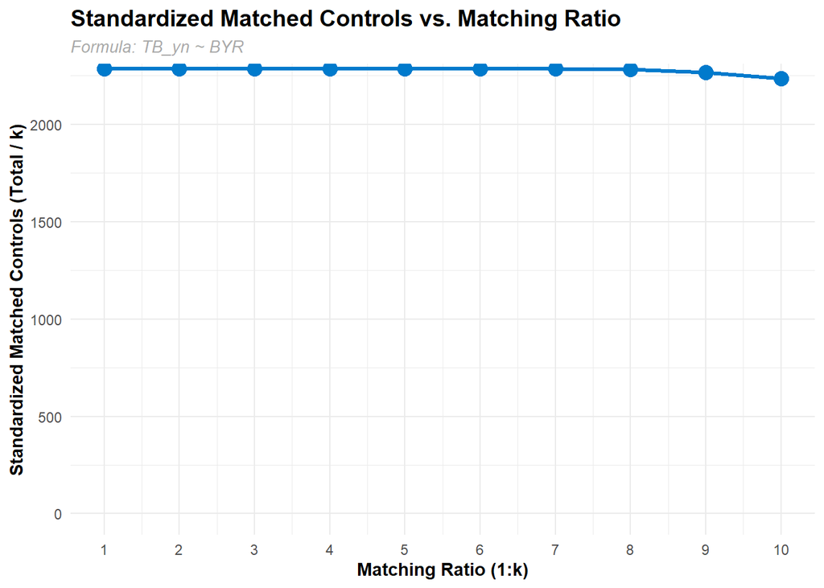

```r
# We will use adjust this based on the matching results
byr_caliper <- 1

model_byr_caliper <- matchit(TB_yn ~ BYR,
                      data = match_byr,
                      distance = "glm",
                      link = "probit",
                      caliper = byr_caliper)


matched_df <- index(model_byr_caliper)
check_random_pairs(matched_df, n_pairs = 5)
```

```
## # A tibble: 9 × 17
##   recidnum   tb_first_date age_tb age_death   BYR   DYR initstat TB_yn wnd_yn
##   <chr>              <dbl>  <dbl>     <dbl> <dbl> <dbl> <chr>    <dbl>  <int>
## 1 2404502109          1862     41        41  1821  1862 OH           1      0
## 2 203004127             NA     NA        85  1821  1906 ME           0      0
## 3 2204205021          1863     19        34  1844  1878 IN           1      1
## 4 2502209049            NA     NA        66  1844  1910 WI           0      1
## 5 2302805021          1861     28        79  1833  1912 MI           1      0
## 6 1100907050            NA     NA        81  1833  1914 DE           0      0
## 7 2206908007          1863     22        22  1841  1863 IN           1      0
## 8 2502303003          1864     22        26  1842  1868 WI           1      0
## 9 2407804036            NA     NA        74  1842  1916 OH           0      0
## # ℹ 8 more variables: lst1_hgt <dbl>, distance <dbl>, weights <dbl>,
## #   subclass <fct>, status <dbl>, tb_year <dbl>, index_year <dbl>,
## #   survival_time <dbl>
```

```r
summary(model_byr_caliper)
```

```
##
## Call:
## matchit(formula = TB_yn ~ BYR, data = match_byr, distance = "glm",
##     link = "probit", caliper = byr_caliper)
##
## Summary of Balance for All Data:
##          Means Treated Means Control Std. Mean Diff. Var. Ratio eCDF Mean
## distance        0.0824        0.0824          0.0000     0.9355    0.0055
## BYR          1837.1535     1837.1515          0.0002     0.9355    0.0055
##          eCDF Max
## distance   0.0247
## BYR        0.0247
##
## Summary of Balance for Matched Data:
##          Means Treated Means Control Std. Mean Diff. Var. Ratio eCDF Mean
## distance        0.0824        0.0824               0     0.9999         0
## BYR          1837.1535     1837.1533               0     0.9999         0
##          eCDF Max Std. Pair Dist.
## distance   0.0004               0
## BYR        0.0004               0
##
## Sample Sizes:
##           Control Treated
## All         25474    2287
## Matched      2287    2287
## Unmatched   23187       0
## Discarded       0       0
```

### Age at First Enlistment

Next, age at first enlistment:

```r
match_lst <- cbind(match_byr, "first_lst" = lst_df$first_lst, "age_lst" = lst_df$age_lst)
match_lst <- remove_blank(match_lst) |>
  drop_na(age_lst)


# lst diagnostics
nrow(match_lst |> filter(TB_yn == 1))
```

```
## [1] 2312
```

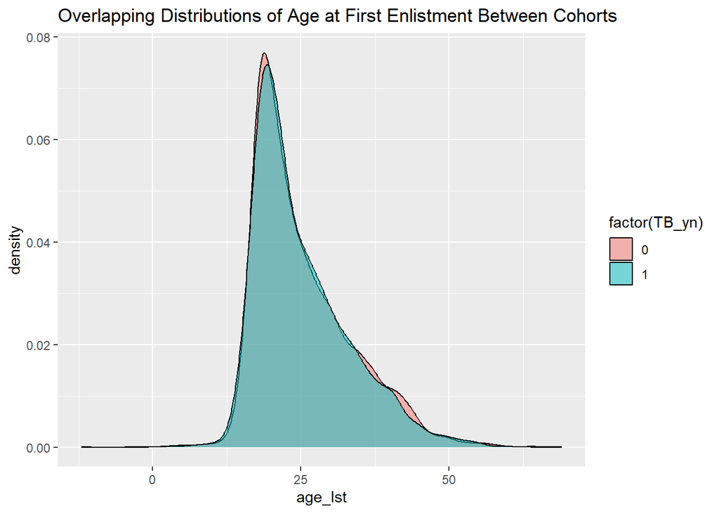

```r
ggplot(match_lst, aes(x = age_lst, fill = factor(TB_yn))) +
  geom_density(alpha = 0.5) +
  labs(title = "Overlapping Distributions of Age at First Enlistment Between Cohorts")
```

```r
# Run matching algorithm
model_lst <- matchit(TB_yn ~ BYR + age_lst,
                      data = match_lst,
                      distance = "glm",
                      link = "probit",
                     caliper = c(age_lst = 1, BYR = 1),
                     ratio = 5)

# INDEX
matched_df <- index(model_lst)

check_random_pairs(matched_df, n_pairs = 5)
```

```
## # A tibble: 29 × 19
##    recidnum   tb_first_date age_tb age_death   BYR   DYR initstat TB_yn wnd_yn
##    <chr>              <dbl>  <dbl>     <dbl> <dbl> <dbl> <chr>    <dbl>  <int>
##  1 203004020           1864     41        60  1823  1883 ME           1      1
##  2 200904160             NA     NA        42  1823  1865 ME           0      0
##  3 2406207066            NA     NA        53  1823  1876 OH           0      0
##  4 3300609048            NA     NA        87  1822  1909 MN           0      0
##  5 2102307050            NA     NA        43  1822  1865 IL           0      0
##  6 2505301009          1863     23        44  1840  1884 WI           1      0
##  7 2200903126            NA     NA        72  1840  1912 IN           0      0
##  8 2105101075            NA     NA        67  1840  1907 IL           0      0
##  9 3400602094            NA     NA        67  1840  1907 MO           0      1
## 10 2404109022            NA     NA        43  1840  1883 OH           0      1
## # ℹ 19 more rows
## # ℹ 10 more variables: lst1_hgt <dbl>, first_lst <dbl>, age_lst <dbl>,
## #   distance <dbl>, weights <dbl>, subclass <fct>, status <dbl>, tb_year <dbl>,
## #   index_year <dbl>, survival_time <dbl>
```

```r
summary(model_lst)
```

```
##
## Call:
## matchit(formula = TB_yn ~ BYR + age_lst, data = match_lst, distance = "glm",
##     link = "probit", caliper = c(age_lst = 1, BYR = 1), ratio = 5)
##
## Summary of Balance for All Data:
##          Means Treated Means Control Std. Mean Diff. Var. Ratio eCDF Mean
## distance        0.0833        0.0833          0.0251     0.9335    0.0062
## BYR          1837.1574     1837.1518          0.0007     0.9367    0.0057
## age_lst        25.0770       25.2791         -0.0255     0.9322    0.0037
##          eCDF Max
## distance   0.0161
## BYR        0.0254
## age_lst    0.0150
##
## Summary of Balance for Matched Data:
##          Means Treated Means Control Std. Mean Diff. Var. Ratio eCDF Mean
## distance        0.0833        0.0833          0.0002     0.9998    0.0001
## BYR          1837.1574     1837.1270          0.0038     1.0119    0.0009
## age_lst        25.0770       25.0778         -0.0001     0.9998    0.0000
##          eCDF Max Std. Pair Dist.
## distance   0.0013          0.0007
## BYR        0.0043          0.0174
## age_lst    0.0003          0.0004
##
## Sample Sizes:
##           Control Treated
## All         25442    2312
## Matched     11560    2312
## Unmatched   13882       0
## Discarded       0       0
```

```r
check_matching_ratio(
  match_formula = TB_yn ~ BYR + age_lst,
  match_data = match_lst,
  my_calipers = c(BYR = 1, age_lst = 1)
)
```

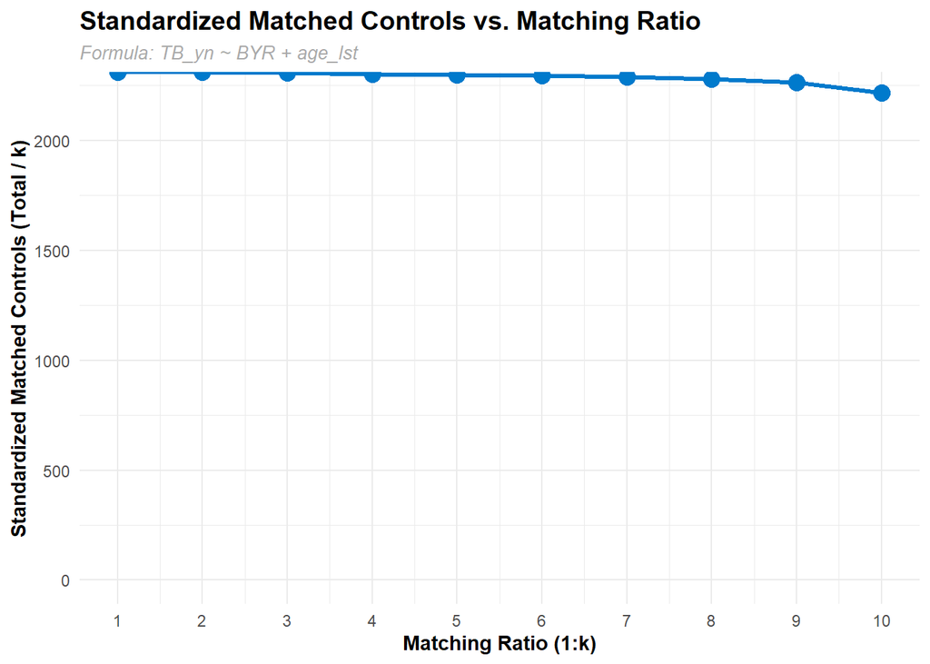

And finally, height at enlistment (drop???):

```r
match_hgt <- remove_blank(match_lst) |>
  drop_na(lst1_hgt)

nrow(match_hgt |> filter(TB_yn == 1))
```

```
## [1] 1941
```

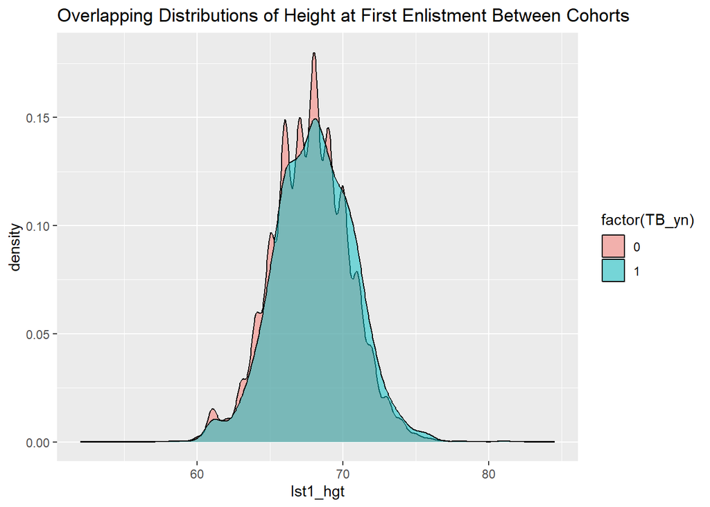

```r
ggplot(match_hgt, aes(x = lst1_hgt, fill = factor(TB_yn))) +
  geom_density(alpha = 0.5) +
  labs(title = "Overlapping Distributions of Height at First Enlistment Between Cohorts")
```

```r
# Run matching algorithm
model_hgt <- matchit(TB_yn ~ BYR + age_lst + lst1_hgt,
                      data = match_hgt,
                      distance = "glm",
                      link = "probit",
                     caliper = c(age_lst = 1, BYR = 1, lst1_hgt = 1),
                     ratio = 5
                    # exact = ~BYR + age_lst + lst1_hgt)
)
# INDEX
matched_df <- index(model_hgt)

check_random_pairs(matched_df, n_pairs = 5)
```

```
## # A tibble: 29 × 19
##    recidnum   tb_first_date age_tb age_death   BYR   DYR initstat TB_yn wnd_yn
##    <chr>              <dbl>  <dbl>     <dbl> <dbl> <dbl> <chr>    <dbl>  <int>
##  1 2204403045          1864     23        74  1841  1915 IN           1      0
##  2 2302905107            NA     NA        68  1847  1915 MI           0      0
##  3 1420503033            NA     NA        73  1841  1914 PA           0      1
##  4 1415508027            NA     NA        76  1841  1917 PA           0      1
##  5 5102306024            NA     NA        47  1843  1890 KY           0      0
##  6 2300109005          1862     29        54  1833  1887 MI           1      0
##  7 2301009165            NA     NA        79  1833  1912 MI           0      1
##  8 1408411102            NA     NA        87  1833  1920 PA           0      0
##  9 2405509090            NA     NA        73  1827  1900 OH           0      1
## 10 2202309001            NA     NA        86  1833  1919 IN           0      0
## # ℹ 19 more rows
## # ℹ 10 more variables: lst1_hgt <dbl>, first_lst <dbl>, age_lst <dbl>,
## #   distance <dbl>, weights <dbl>, subclass <fct>, status <dbl>, tb_year <dbl>,
## #   index_year <dbl>, survival_time <dbl>
```

```r
summary(model_hgt)
```

```
##
## Call:
## matchit(formula = TB_yn ~ BYR + age_lst + lst1_hgt, data = match_hgt,
##     distance = "glm", link = "probit", caliper = c(age_lst = 1,
##         BYR = 1, lst1_hgt = 1), ratio = 5)
##
## Summary of Balance for All Data:
##          Means Treated Means Control Std. Mean Diff. Var. Ratio eCDF Mean
## distance        0.0847        0.0836          0.1177     1.0334    0.0308
## BYR          1837.2084     1837.1939          0.0018     0.9409    0.0057
## age_lst        25.1185       25.2673         -0.0187     0.9378    0.0034
## lst1_hgt       68.0473       67.7372          0.1165     0.9978    0.0197
##          eCDF Max
## distance   0.0569
## BYR        0.0270
## age_lst    0.0143
## lst1_hgt   0.0488
##
## Summary of Balance for Matched Data:
##          Means Treated Means Control Std. Mean Diff. Var. Ratio eCDF Mean
## distance        0.0847        0.0847          0.0007     1.0100    0.0003
## BYR          1837.2084     1837.5254         -0.0395     1.1225    0.0074
## age_lst        25.1185       24.9133          0.0258     1.1015    0.0050
## lst1_hgt       68.0473       68.0230          0.0091     1.0081    0.0018
##          eCDF Max Std. Pair Dist.
## distance   0.0026          0.0045
## BYR        0.0293          0.3787
## age_lst    0.0214          0.3605
## lst1_hgt   0.0069          0.0720
##
## Sample Sizes:
##           Control Treated
## All         21247    1941
## Matched      9705    1941
## Unmatched   11542       0
## Discarded       0       0
```

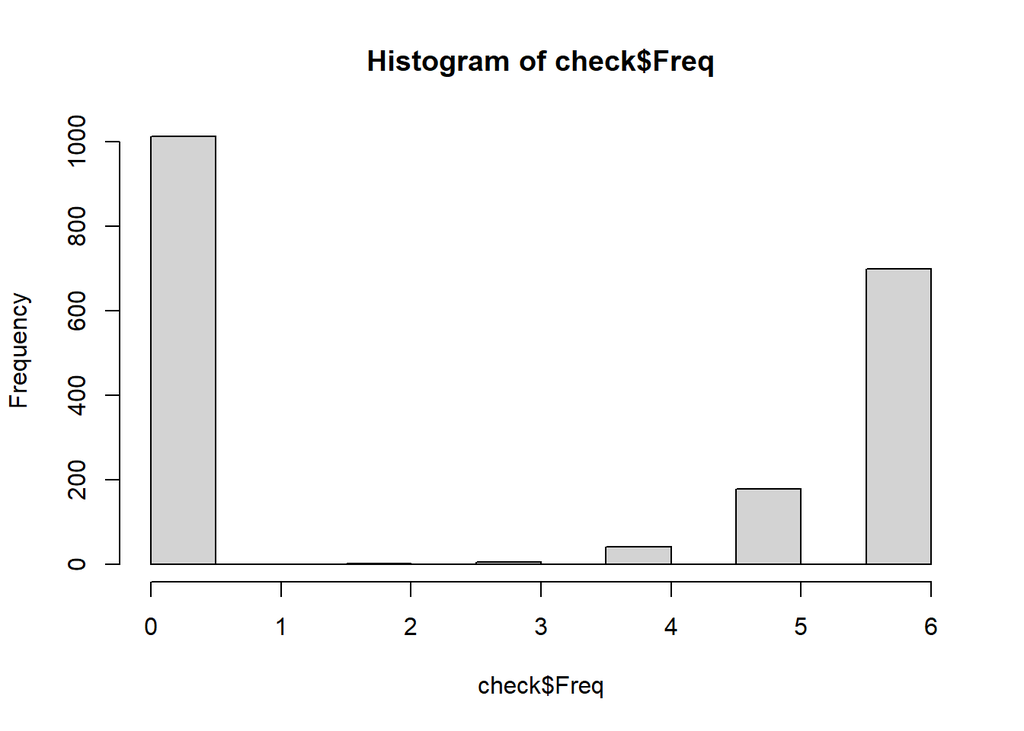

```r
check <- as.data.frame(table(matched_df$subclass))
hist(check$Freq)
```

```r
check_matching_ratio(
  match_formula = TB_yn ~ BYR + age_lst + lst1_hgt,
  match_data = match_hgt,
  my_calipers = c(BYR = 1, age_lst = 1, lst1_hgt = 1)
)
```

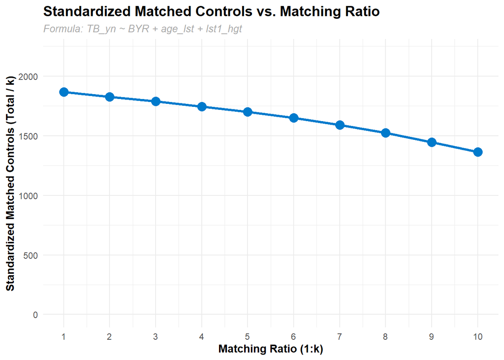

Then state of first enlistment:

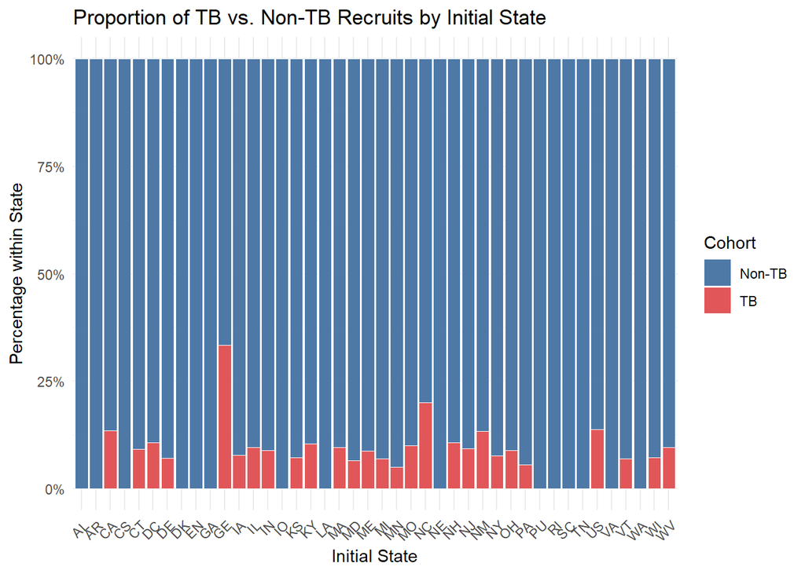

```r
match_state <- as.data.frame(match_hgt) |>
  mutate(
    initstat = remove_blank(initstat)
  ) |>
  drop_na(initstat)


ggplot(match_state, aes(x = initstat, fill = factor(TB_yn))) +
  geom_bar(position = "fill", color = "white", linewidth = 0.2) +
  # Convert the y-axis
  scale_y_continuous(labels = percent_format()) +
  scale_fill_manual(
    values = c("0" = "#4E79A7", "1" = "#E15759"),
    labels = c("0" = "Non-TB", "1" = "TB")
  ) +
  labs(
    title = "Proportion of TB vs. Non-TB Recruits by Initial State",
    x = "Initial State",
    y = "Percentage within State",
    fill = "Cohort"
  ) +
  theme_minimal() +
  theme(axis.text.x = element_text(angle = 45, hjust = 1, vjust = 1))
```

```r
# Run matching algorithm
model_state <- matchit(TB_yn ~ BYR + age_lst + lst1_hgt + initstat,
                      data = match_state,
                      distance = "glm",
                      link = "probit",
                      caliper = c(age_lst = 1, BYR = 1, lst1_hgt = 1),
                      ratio = 8,
                      exact = ~initstat)
```

```r
# INDEX
matched_df <- index(model_state)

check_random_pairs(matched_df, n_pairs = 20)
```

```
## # A tibble: 170 × 19
##    recidnum   tb_first_date age_tb age_death   BYR   DYR initstat TB_yn wnd_yn
##    <chr>              <dbl>  <dbl>     <dbl> <dbl> <dbl> <chr>    <dbl>  <int>
##  1 2202403213          1864     24        78  1840  1918 IN           1      1
##  2 2202403129            NA     NA        67  1840  1907 IN           0      0
##  3 2204205004            NA     NA        78  1833  1911 IN           0      0
##  4 2214607038            NA     NA        66  1844  1910 IN           0      0
##  5 2204403082            NA     NA        77  1843  1920 IN           0      1
##  6 2203502095            NA     NA        30  1835  1865 IN           0      0
##  7 2201311087            NA     NA        54  1832  1886 IN           0      0
##  8 2202607026            NA     NA        46  1836  1882 IN           0      0
##  9 2202907104            NA     NA        82  1832  1914 IN           0      1
## 10 2107905040          1862     29        74  1833  1907 IL           1      0
## # ℹ 160 more rows
## # ℹ 10 more variables: lst1_hgt <dbl>, first_lst <dbl>, age_lst <dbl>,
## #   distance <dbl>, weights <dbl>, subclass <fct>, status <dbl>, tb_year <dbl>,
## #   index_year <dbl>, survival_time <dbl>
```

```r
summary(model_state)
```

```
##
## Call:
## matchit(formula = TB_yn ~ BYR + age_lst + lst1_hgt + initstat,
##     data = match_state, distance = "glm", link = "probit", exact = ~initstat,
##     caliper = c(age_lst = 1, BYR = 1, lst1_hgt = 1), ratio = 8)
##
## Summary of Balance for All Data:
##            Means Treated Means Control Std. Mean Diff. Var. Ratio eCDF Mean
## distance          0.0872        0.0833          0.2166     1.1248    0.0635
## BYR            1837.2079     1837.1937          0.0018     0.9421    0.0057
## age_lst          25.1198       25.2668         -0.0185     0.9373    0.0034
## lst1_hgt         68.0499       67.7371          0.1176     0.9976    0.0199
## initstatAL        0.0000        0.0002         -0.0143          .    0.0002
## initstatAR        0.0000        0.0000         -0.0072          .    0.0000
## initstatCA        0.0139        0.0082          0.0494          .    0.0058
## initstatCS        0.0000        0.0000         -0.0072          .    0.0000
## initstatCT        0.0181        0.0163          0.0137          .    0.0018
## initstatDC        0.0031        0.0024          0.0134          .    0.0007
## initstatDE        0.0108        0.0128         -0.0190          .    0.0020
## initstatDK        0.0000        0.0000         -0.0072          .    0.0000
## initstatEN        0.0000        0.0000         -0.0072          .    0.0000
## initstatGA        0.0000        0.0000         -0.0072          .    0.0000
## initstatGE        0.0005        0.0001          0.0186          .    0.0004
## initstatIA        0.0517        0.0553         -0.0165          .    0.0037
## initstatIL        0.1426        0.1219          0.0590          .    0.0206
## initstatIN        0.1296        0.1208          0.0262          .    0.0088
## initstatIO        0.0000        0.0001         -0.0101          .    0.0001
## initstatKS        0.0088        0.0101         -0.0144          .    0.0013
## initstatKY        0.0351        0.0274          0.0421          .    0.0078
## initstatLA        0.0000        0.0000         -0.0072          .    0.0000
## initstatMA        0.0201        0.0172          0.0210          .    0.0029
## initstatMD        0.0083        0.0106         -0.0263          .    0.0024
## initstatME        0.0165        0.0155          0.0081          .    0.0010
## initstatMI        0.0418        0.0512         -0.0468          .    0.0094
## initstatMN        0.0067        0.0115         -0.0591          .    0.0048
## initstatMO        0.0424        0.0347          0.0379          .    0.0076
## initstatNC        0.0005        0.0002          0.0144          .    0.0003
## initstatNE        0.0000        0.0001         -0.0101          .    0.0001
## initstatNH        0.0243        0.0185          0.0374          .    0.0058
## initstatNJ        0.0212        0.0187          0.0175          .    0.0025
```

[output cut: 150 more lines]

```
## initstatTN   0.0000          0.0000
## initstatUS   0.0000          0.0000
## initstatVA   0.0000          0.0000
## initstatVT   0.0000          0.0000
## initstatWA   0.0000          0.0000
## initstatWI   0.0000          0.0000
## initstatWV   0.0000          0.0000
##
## Sample Sizes:
##               Control Treated
## All           21226.     1936
## Matched (ESS) 14257.7    1935
## Matched       15019.     1935
## Unmatched      6207.        1
## Discarded         0.        0
```

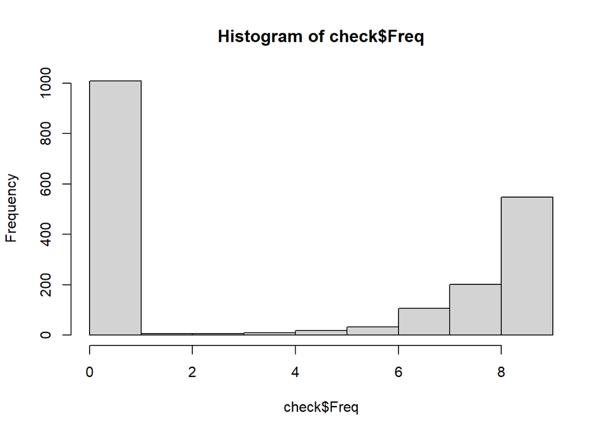

```r
check <- as.data.frame(table(matched_df$subclass))
hist(check$Freq)
```

```r
check_matching_ratio(
  match_formula = TB_yn ~ BYR + age_lst + lst1_hgt+ initstat,
  match_data = match_state,
  my_calipers = c(BYR = 1, age_lst = 1, lst1_hgt = 1)
)
```

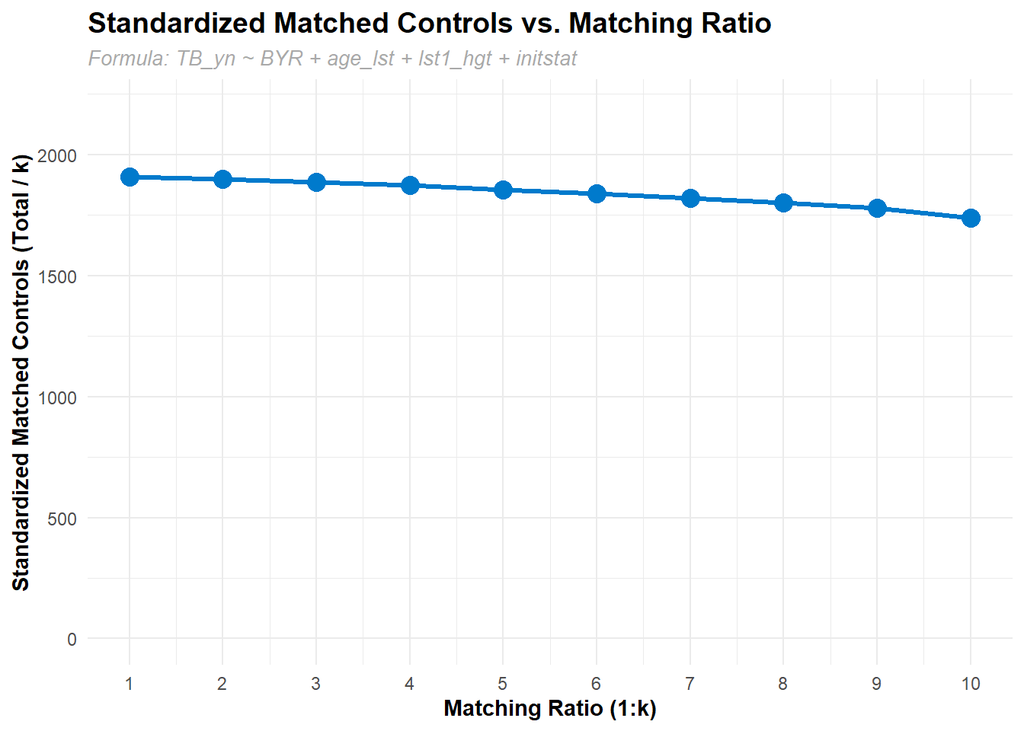